Longitudinal Analysis of Orthodontic Growth

Data as of October 25, 2026 | Analysis run on October 31, 2026

Theme:

## **Analysis Overview**

This analysis examines changes in craniofacial distance over time using the Orthodont dataset from the nlme R package. The dataset includes 108 measurements from 27 children (16 boys and 11 girls), each assessed at ages 8, 10, 12, and 14 years.

We used linear mixed-effects models (LMMs) to account for repeated measurements within children and address two main research questions:

- Does craniofacial distance increase with age?
- Do boys and girls differ in their rates of change over time?

We compared random-intercept and random-intercept-plus-slope models to select an appropriate random-effects structure. We then evaluated the age × sex interaction to assess differences in growth rates between boys and girls.

Results include model comparisons, estimated annual changes with 95% confidence intervals, model-based predicted trajectories, and diagnostic assessments.

## **Age Effect on Craniofacial Distance**

We used linear mixed-effects models to evaluate changes in craniofacial distance with age. Since each child was measured repeatedly, a random intercept was included to account for differences between children and within-child correlation.

To determine whether children also differed in their growth rates, we compared two models:

- **Random Intercept Only:** Allows each child to have a different baseline measurement but assumes the same growth rate.
- **Random Intercept + Random Slope:** Allows each child to have a different baseline measurement and growth rate.

The models were compared using a likelihood ratio test (LRT).

Comparison of Random-Effects Structures

| Model | AIC | BIC | LRT Chi-square | df | p-value |
| --- | --- | --- | --- | --- | --- |
| Random Intercept Only | 451.39 | 462.12 | — | — |  |
| Random Intercept + Slope | 451.21 | 467.30 | 4.18 | 2 | 0.124 |

Adding a random slope did not significantly improve model fit (LRT: χ²(2) = 4.18, p = 0.124). Therefore, the simpler random-intercept model was selected.

The estimated annual change in craniofacial distance was 0.66 mm/year.

Estimated Annual Change in Craniofacial Distance

| Outcome | Annual Change (mm/year) | Lower 95% CI | Upper 95% CI | p-value |
| --- | --- | --- | --- | --- |
| Craniofacial Distance | 0.660 | 0.538 | 0.783 | <0.001 |

Model diagnostics were generally acceptable, with some deviations from normality in the distribution tails. All observations were retained.

## **Sex Differences in Craniofacial Growth**

We evaluated whether boys and girls had different rates of change in craniofacial distance over time.

Two linear mixed-effects models with random intercepts were fitted:

- **Without Interaction:** Includes age and sex, assuming the same growth rate for boys and girls.
- **With Interaction:** Includes age, sex, and the age × sex interaction, allowing different growth rates for boys and girls.

We compared the models using a likelihood ratio test (LRT).

Comparison of Models With and Without Age × Sex Interaction

| Model | AIC | BIC | LRT Chi-square | df | p-value |
| --- | --- | --- | --- | --- | --- |
| Without Interaction | 444.86 | 458.27 | — | — |  |
| With Interaction | 440.64 | 456.73 | 6.22 | 1 | 0.013 |

Adding the age × sex interaction significantly improved model fit (LRT: χ²(1) = 6.22, p = 0.013). Therefore, the interaction model was selected.

### Estimated Annual Growth Rates by Sex

We estimated the annual change in craniofacial distance for boys and girls using the selected model.

Estimated Annual Growth Rates by Sex

| Sex | Annual Change (mm/year) | Lower 95% CI | Upper 95% CI | p-value |
| --- | --- | --- | --- | --- |
| Male | 0.784 | 0.630 | 0.939 | <0.001 |
| Female | 0.480 | 0.294 | 0.665 | <0.001 |

Craniofacial distance increased with age in both groups. The estimated annual increase was 0.784 mm/year for boys and 0.48 mm/year for girls. Boys showed a greater annual increase than girls.

### Model-Based Predicted Trajectories

[figure not shown]

### Model Diagnostics

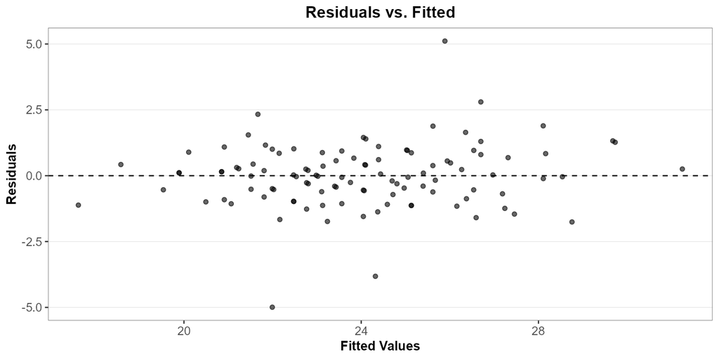

## **Summary**

Craniofacial distance increased with age in both boys and girls. The random-intercept-only model was selected because adding a random slope did not significantly improve model fit.

The age × sex interaction was statistically significant (p = 0.013), indicating that growth rates differed between boys and girls. The estimated annual increase was 0.784 mm/year (95% CI: 0.630–0.939) for boys and 0.480 mm/year (95% CI: 0.294–0.665) for girls.

Model-based predicted trajectories showed a steeper increase in craniofacial distance among boys. Model diagnostics indicated generally acceptable fit, with some deviations from normality in the distribution tails.

Overall, the analysis demonstrates how linear mixed-effects models can be used to evaluate longitudinal changes, account for repeated measurements, and compare growth trajectories between groups.